# TFM classificació dispositius

En aquest document s’intentarà classificar els dispositius On es vol aconseguir: - Si els dispositius son estàtics o estan en moviment - Si son els dispositius son esporàdics o son habituals a la xarxa

- Per poder identificar millor els dispositius s’afegirà informació adicional sobre els fabricants dels dispositius per poder cercar una relació

## Carregar la base de dades

El primer pas ser cargar les dades tot un dia.

```r
dades = read.csv("~/Escritorio/TFM/observacionsEstiu20190724mod.csv", header = TRUE, sep = ';')
str(dades)
```

```
## 'data.frame':    3833267 obs. of  10 variables:
##  $ idreg    : Factor w/ 3833267 levels "000d4f7a-20bd-11ea-9849-080027f7d687",..: 631014 631015 631016 631017 631018 631019 631020 631021 631022 631023 ...
##  $ clientmac: Factor w/ 224375 levels "00:00:00:44:78:9c",..: 130496 48874 222287 1784 158705 163081 72 163081 163081 73 ...
##  $ lat      : num  39.6 39.6 39.6 39.6 39.6 ...
##  $ lng      : num  2.63 2.64 2.64 2.64 2.64 ...
##  $ seendate : logi  NA NA NA NA NA NA ...
##  $ seentime : int  1563988648 1564008125 1563998527 1563979981 1563971171 1563943361 1563930230 1563945813 1563946242 1564010537 ...
##  $ apmac    : Factor w/ 173 levels "00:18:0a:03:04:bc",..: 25 26 26 26 26 27 27 27 27 27 ...
##  $ model    : logi  NA NA NA NA NA NA ...
##  $ ssid     : logi  NA NA NA NA NA NA ...
##  $ lloc     : logi  NA NA NA NA NA NA ...
```

```r
head(dades)
```

|  | idreg | clientmac | lat | lng | seendate | seentime | apmac | model | ssid | lloc |
| --- | --- | --- | --- | --- | --- | --- | --- | --- | --- | --- |
| 1 | 2e14a25a-20b9-11ea-9849-080027f7d687 | a8:0c:63:b2:3f:6c | 39.56706 | 2.630230 | NA | 1563988648 | 00:18:0a:04:74:d0 | NA | NA | NA |
| 2 | 2e14a25b-20b9-11ea-9849-080027f7d687 | 38:ca:da:97:f2:00 | 39.56675 | 2.644041 | NA | 1564008125 | 00:18:0a:04:78:72 | NA | NA | NA |
| 3 | 2e14a25c-20b9-11ea-9849-080027f7d687 | f8:95:ea:07:3c:e4 | 39.56675 | 2.644040 | NA | 1563998527 | 00:18:0a:04:78:72 | NA | NA | NA |
| 4 | 2e14a25d-20b9-11ea-9849-080027f7d687 | 00:1a:dd:54:4c:24 | 39.56689 | 2.643955 | NA | 1563979981 | 00:18:0a:04:78:72 | NA | NA | NA |
| 5 | 2e14a25e-20b9-11ea-9849-080027f7d687 | c0:a6:00:68:16:ff | 39.56675 | 2.644041 | NA | 1563971171 | 00:18:0a:04:78:72 | NA | NA | NA |
| 6 | 2e14a25f-20b9-11ea-9849-080027f7d687 | c8:3a:35:dc:92:a3 | 39.56665 | 2.643939 | NA | 1563943361 | 00:18:0a:04:a1:ca | NA | NA | NA |

Al haver més de tres milions de registres. És crearà un data set d’entrenament per poder crear l’algoritme i reduir el temps d’execució.

```r
dades.train = sample(1:dim(dades) [1], round(dim(dades)[1]*0.01),replace = FALSE)
dades.train= dades[dades.train,]
dades.train = data.frame(dades.train)
str(dades.train)
```

```
## 'data.frame':    38333 obs. of  10 variables:
##  $ idreg    : Factor w/ 3833267 levels "000d4f7a-20bd-11ea-9849-080027f7d687",..: 732648 3787984 172041 1873852 1860237 2899557 2202554 1850091 1644039 471888 ...
##  $ clientmac: Factor w/ 224375 levels "00:00:00:44:78:9c",..: 89608 184471 147926 63516 99770 141182 35700 10125 104692 1549 ...
##  $ lat      : num  39.6 39.6 39.6 39.6 39.6 ...
##  $ lng      : num  2.66 2.65 2.66 2.67 2.65 ...
##  $ seendate : logi  NA NA NA NA NA NA ...
##  $ seentime : int  1563952642 1563983657 1563954401 1563974826 1563966259 1563977668 1563977622 1563981272 1564002879 1563996266 ...
##  $ apmac    : Factor w/ 173 levels "00:18:0a:03:04:bc",..: 95 113 83 17 75 39 21 74 74 25 ...
##  $ model    : logi  NA NA NA NA NA NA ...
##  $ ssid     : logi  NA NA NA NA NA NA ...
##  $ lloc     : logi  NA NA NA NA NA NA ...
```

## Primer identificar els fabricants dels dispositius

La primera fase es llegir es obtenir la base de dades on conté tots els fabricants de dispositius i que contengui la seva assignació

```r
tipos = read.csv("~/Escritorio/TFM/oui.csv", header = TRUE, sep = ',')
str(tipos)
```

```
## 'data.frame':    27761 obs. of  4 variables:
##  $ Registry            : Factor w/ 1 level "MA-L": 1 1 1 1 1 1 1 1 1 1 ...
##  $ Assignment          : Factor w/ 27758 levels "000000","000001",..: 8791 12546 13378 27203 18038 23865 21711 16628 22658 25600 ...
##  $ Organization.Name   : Factor w/ 17873 levels "\t Xiamen Ursalink Technology Co., Ltd.",..: 950 7297 12818 3074 12592 2485 7674 10853 10853 3282 ...
##  $ Organization.Address: Factor w/ 18775 levels ""," \tAKAMONDORI Bldg, 30-20, Ohsu 3-chome, Minami-ku, Nagoya Aichi Pref. JP 457-8520 ",..: 4380 10933 438 10256 15168 15207 14279 9042 9042 13205 ...
```

```r
head(tipos)
```

|  | Registry | Assignment | Organization.Name | Organization.Address |
| --- | --- | --- | --- | --- |
| 1 | MA-L | 002272 | American Micro-Fuel Device Corp. | 2181 Buchanan Loop Ferndale WA US 98248 |
| 2 | MA-L | 00D0EF | IGT | 9295 PROTOTYPE DRIVE RENO NV US 89511 |
| 3 | MA-L | 086195 | Rockwell Automation | 1 Allen-Bradley Dr. Mayfield Heights OH US 44124-6118 |
| 4 | MA-L | F4BD9E | Cisco Systems, Inc | 80 West Tasman Drive San Jose CA US 94568 |
| 5 | MA-L | 5885E9 | Realme Chongqing MobileTelecommunications Corp Ltd | No.24 Nichang Boulevard, Huixing Block, Yubei District, Chongqing. Chongqing China CN 401120 |
| 6 | MA-L | BC2392 | BYD Precision Manufacture Company Ltd. | No.3001, Bao He Road, Baolong Industrial, Longgang Street,Longgang Zone, Shenzhen shenzhen CN 518116 |

Cada direcció conté la mac, l’organització i direcció

## Preparar les dades

Primer es carguen les llibreries per realitzar les següents passes

```r
library(stringr)
library(dplyr)
```

```r
# library(ggplot2)
```

Eliminam les mac dels clients repetits perquè no volem comptar e mateix dispositiu varies vegades

```r
dades.trainb = dades.train[!duplicated(dades.train$clientmac), ]
```

Una vegada fet se processarà la direcció mac perquè sigui igual a la dels tipus de oui.

```r
my_string = stringr::str_replace_all(dades.trainb$clientmac, ":", "") # Eliminamos los dos puntos de la dirección mac
my_string = substr(my_string,1,6) # Solo nos quedamos con la oui de la mac
my_string = toupper(my_string) # Lo pasamos a mayúsculas
```

El resultat obtingut, un vector, se covertirà en una columna as factor i s’afegirá a la base de dades dels dispositius.

```r
Assignment = as.factor(my_string)
dades.trainb = data.frame(dades.trainb, Assignment)
str(dades.trainb)
```

```
## 'data.frame':    21374 obs. of  11 variables:
##  $ idreg     : Factor w/ 3833267 levels "000d4f7a-20bd-11ea-9849-080027f7d687",..: 732648 3787984 172041 1873852 1860237 2899557 2202554 1850091 1644039 471888 ...
##  $ clientmac : Factor w/ 224375 levels "00:00:00:44:78:9c",..: 89608 184471 147926 63516 99770 141182 35700 10125 104692 1549 ...
##  $ lat       : num  39.6 39.6 39.6 39.6 39.6 ...
##  $ lng       : num  2.66 2.65 2.66 2.67 2.65 ...
##  $ seendate  : logi  NA NA NA NA NA NA ...
##  $ seentime  : int  1563952642 1563983657 1563954401 1563974826 1563966259 1563977668 1563977622 1563981272 1564002879 1563996266 ...
##  $ apmac     : Factor w/ 173 levels "00:18:0a:03:04:bc",..: 95 113 83 17 75 39 21 74 74 25 ...
##  $ model     : logi  NA NA NA NA NA NA ...
##  $ ssid      : logi  NA NA NA NA NA NA ...
##  $ lloc      : logi  NA NA NA NA NA NA ...
##  $ Assignment: Factor w/ 2370 levels "0000AE","000272",..: 1184 1974 1782 922 1239 1696 563 248 1299 44 ...
```

## Obtenció de resultats

Una vegada ja tengut els diferents dispositius se combina amb la base de dades dels tipus de dispositius a través de la mateix columna

```r
combine = merge( dades.trainb, tipos, by = "Assignment")
head(combine)
```

|  | Assignment | idreg | clientmac | lat | lng | seendate | seentime | apmac | model | ssid | lloc | Registry | Organization.Name | Organization.Address |
| --- | --- | --- | --- | --- | --- | --- | --- | --- | --- | --- | --- | --- | --- | --- |
| 1 | 0000AE | a19fa4a0-20bc-11ea-9849-080027f7d687 | 00:00:ae:a6:8b:3b | 39.57258 | 2.642459 | NA | 1563945306 | 00:18:0a:03:0d:04 | NA | NA | NA | MA-L | DASSAULT ELECTRONIQUE | 55, QUAI MARCEL DASSAULT FR |
| 2 | 000272 | bf3da10c-20b9-11ea-9849-080027f7d687 | 00:02:72:87:1d:83 | 39.56337 | 2.652535 | NA | 1563952384 | 00:18:0a:03:12:32 | NA | NA | NA | MA-L | CC&C Technologies, Inc. | 8F, 150, Chien I Rd., Chung Ho City, Taipei County 235 Taiwan TW R.O.C. |
| 3 | 00037F | 48f182d0-20bd-11ea-9849-080027f7d687 | 00:03:7f:96:d7:f9 | 39.56858 | 2.642401 | NA | 1563989631 | 00:18:0a:03:0d:28 | NA | NA | NA | MA-L | Atheros Communications, Inc. | 5480 Great America Parkway Santa Clara CA US 95054 |
| 4 | 0003AC | 610e3ecf-20bc-11ea-9849-080027f7d687 | 00:03:ac:19:18:0e | 39.57528 | 2.652808 | NA | 1563959851 | 88:15:44:2d:40:40 | NA | NA | NA | MA-L | Fronius Schweissmaschinen | Günter Fronius-Straße 1 AT |
| 5 | 0003AC | 469c79e0-20bc-11ea-9849-080027f7d687 | 00:03:ac:1d:2c:6f | 39.57565 | 2.653670 | NA | 1563975498 | 88:15:44:59:61:e0 | NA | NA | NA | MA-L | Fronius Schweissmaschinen | Günter Fronius-Straße 1 AT |
| 6 | 0003AC | 51c9e9ed-20bc-11ea-9849-080027f7d687 | 00:03:ac:1a:07:2f | 39.56795 | 2.647998 | NA | 1563970655 | 88:15:44:2c:13:00 | NA | NA | NA | MA-L | Fronius Schweissmaschinen | Günter Fronius-Straße 1 AT |

Plotetjam les dades

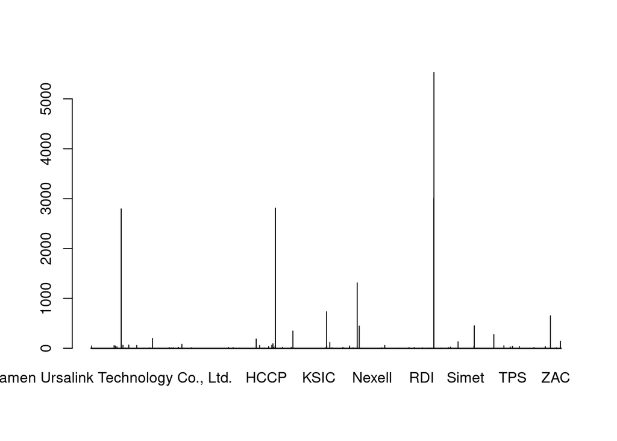

```r
plot(combine$Organization.Name)
```

Proba per mirar cuants de dipsositius hi ha de apple

```r
proba = combine[ combine$Organization.Name == "Apple, Inc.", ]
length(proba$Organization.Name)
```

```
## [1] 2796
```

Ordenam i veim la cuantitat de dispositius que hi ha

```r
mt = combine[order(combine$Organization.Name), ]
summary(mt$Organization.Name)
```

```
##                                    Samsung Electronics Co.,Ltd
##                                                           5532
##                            SAMSUNG ELECTRO-MECHANICS(THAILAND)
##                                                           3002
##                                    HUAWEI TECHNOLOGIES CO.,LTD
##                                                           2809
##                                                    Apple, Inc.
##                                                           2796
##                        Motorola Mobility LLC, a Lenovo Company
##                                                           1311
##                         LG Electronics (Mobile Communications)
##                                                            733
##                                   Xiaomi Communications Co Ltd
##                                                            652
##                                 Sony Mobile Communications Inc
##                                                            451
##                                 Murata Manufacturing Co., Ltd.
##                                                            447
##                                                Intel Corporate
##                                                            346
##                                                 TCT mobile ltd
##                                                            275
##                                                             BQ
##                                                            199
##                                                   Google, Inc.
##                                                            185
##                                                zte corporation
##                                                            142
##                         Shenzhen TINNO Mobile Technology Corp.
##                                                            131
##                                  Liteon Technology Corporation
##                                                            118
##                                Hon Hai Precision Ind. Co.,Ltd.
##                                                             91
##                   Continental Automotive Czech Republic s.r.o.
##                                                             81
##                                          ASUSTek COMPUTER INC.
##                                                             65
##                                                  HMD Global Oy
##                                                             61
```

[output cut: 145 more lines]

```
##                                                              5
##                                                Routerboard.com
##                                                              5
##                     Shanghai Huaqin Telecom Technology Co.,Ltd
##                                                              5
##                 Spreadtrum Communications (Shanghai) Co., Ltd.
##                                                              5
##                                                         AboCom
##                                                              4
##                                           Airgo Networks, Inc.
##                                                              4
##                                                 BlackBerry RTS
##                                                              4
##                                                        (Other)
##                                                            259
```

Observam que la majoria de dispositius que es connecten són Samsung, Huawei i Apple.

## Possibles errors

Un error que apreix

```r
length(dades.trainb$Assignment) -length(combine$Assignment)
```

```
## [1] 238
```

## Habituals o esporàdic

En aquesta secció es cercarà si els dispositius son de habituals a la xarxa o son esporàdics. -S’ha de mirar per el cas d’un dia: Que el dispositiu estigui conectat varies vegades en un dia es pot considerar. -Un altre sobre els 90 dies: Si un dispositiu es conecta semanalment a la xarxa es pot considerar que es habitual.

Aqui hi ha una primera versió que mirarà les conexions diàries de les persones.

```r
habitual_usuari = list()
for(i in 1:(length(dades.trainb$clientmac)-1)){
  usuari = dades.train[dades.trainb$clientmac[i] == dades.train$clientmac, ]
  leng_usuari = length(usuari$clientmac)

  habitual_usuari[i] = leng_usuari

}
```

```r
vec1 = unlist(habitual_usuari)

length(vec1)
```

```
## [1] 21373
```

```r
quantile(vec1)
```

```
##   0%  25%  50%  75% 100%
##    1    1    1    2  156
```

Una vegada realitzat la lectura. És mostrarà per pantalla el nombre de conexons diaries i la seva mitja

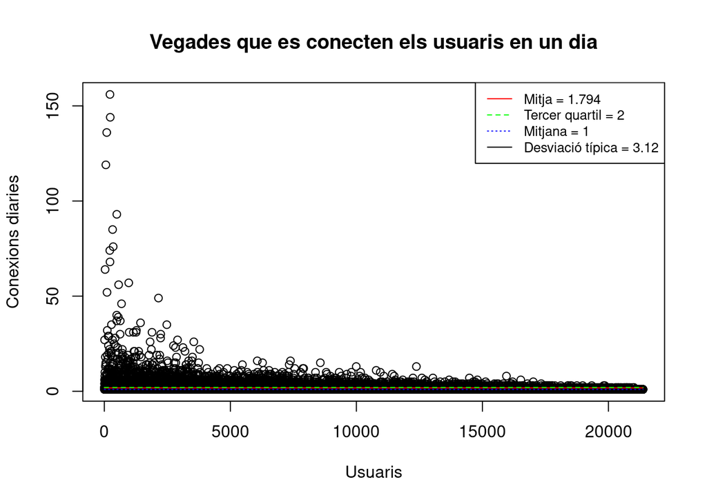

```r
media = sum(vec1)/length(vec1)

tercer_quartil = 2

tercer_quartil_vec = rep(tercer_quartil, length(vec1))

mitjana  = 1

mitjana_vec = rep(mitjana, length(vec1))

media_vec = rep(media, length(vec1))

#Calcular la desviacio típica
desvtip = sd(vec1)

plot(vec1, xlab = "Usuaris", ylab ="Conexions diaries", main = "Vegades que es conecten els usuaris en un dia")
lines(media_vec, col = "red")
lines(tercer_quartil_vec, col = "green", lty = 2)
lines(mitjana_vec, col = "blue", lty = 3)
legend("topright", legend=c("Mitja = 1.794", "Tercer quartil = 2", "Mitjana = 1", "Desviació típica = 3.12"),
       col=c("red", "green", "blue", "black"), lty=1:3, cex=0.8)
```

```r
habitual_usuari_dosomes = list()
contador = 0
for(i in 1:(length(dades.trainb$clientmac)-1)){
  usuari = dades.train[dades.trainb$clientmac[i] == dades.train$clientmac, ]
  leng_usuari = length(usuari$clientmac)

  if( leng_usuari != 1){
    habitual_usuari_dosomes[contador] = leng_usuari
    contador =  contador + 1
  }

}
```

```r
vec1 = unlist(habitual_usuari_dosomes)

length(vec1)
```

```
## [1] 6666
```

```r
quantile(vec1)
```

```
##   0%  25%  50%  75% 100%
##    2    2    2    3  156
```

[figure not shown]

```r
media = sum(vec1)/length(vec1)

tercer_quartil = 3

tercer_quartil_vec = rep(tercer_quartil, length(vec1))

mitjana  = 2

mitjana_vec = rep(mitjana, length(vec1))

media_vec = rep(media, length(vec1))

#Calcular la desviacio típica
desvtip = sd(vec1)


plot(vec1, xlab = "Usuaris", ylab ="Conexions diaries", main = "Vegades que es conecten els usuaris en un dia")
lines(media_vec, col = "red")
lines(tercer_quartil_vec, col = "green", lty = 2)
lines(mitjana_vec, col = "blue", lty = 3)
legend("topright", legend=c("Mitja = 3.5679", "Tercer quartil = 3", "Mitjana = 2", "Desviació típica = 5.27"),
       col=c("red", "green", "blue", "black"), lty=1:3, cex=0.8)
```

```r
media
```

```
## [1] 3.543954
```

# Primera versió de l’algoritme

Si supera aquest contador es considerarà que és un dispositiu habitual a la xarxa. Llavors aqui apareix el primer algortime

```r
min_contador = 3
habitual_usuari = list()

# Start the clock!
ptm <- proc.time()

for(i in 1:(length(dades.trainb$clientmac))){
  usuari = dades.train[dades.trainb$clientmac[i] == dades.train$clientmac, ]
  leng_usuari = length(usuari$clientmac)

  if(leng_usuari >= min_contador){
    habitual_usuari[i] = "habitual"
  } else {
    habitual_usuari[i] = "esporadic"
  }
}

#Finish the clock
proc.time() -ptm
```

```
##    user  system elapsed
## 192.528   0.240 192.774
```

```r
dades.train_habituals = data.frame(unlist(habitual_usuari))


dades.train_habituals = data.frame(dades.trainb, "ClassificacioH/E" = dades.train_habituals)
```

```r
head(dades.train_habituals)
```

|  | idreg | clientmac | lat | lng | seendate | seentime | apmac | model | ssid | lloc | Assignment | unlist.habitual_usuari. |
| --- | --- | --- | --- | --- | --- | --- | --- | --- | --- | --- | --- | --- |
| 54950 | 3201376f-20b9-11ea-9849-080027f7d687 | 78:c3:e9:eb:62:4e | 39.57706 | 2.656507 | NA | 1563952642 | 00:18:0a:da:00:60 | NA | NA | NA | 78C3E9 | esporadic |
| 1374722 | fd11e7b0-20ba-11ea-9849-080027f7d687 | d0:d2:b0:0d:e0:b1 | 39.57541 | 2.653006 | NA | 1563983657 | 88:15:44:59:61:e0 | NA | NA | NA | D0D2B0 | esporadic |
| 3810489 | 0badf7c7-20be-11ea-9849-080027f7d687 | bc:54:51:6c:51:3a | 39.58093 | 2.655280 | NA | 1563954401 | 00:18:0a:5b:6b:70 | NA | NA | NA | BC5451 | esporadic |
| 990317 | 7f3c425a-20ba-11ea-9849-080027f7d687 | 58:b1:0f:14:75:a4 | 39.56125 | 2.665809 | NA | 1563974826 | 00:18:0a:03:12:32 | NA | NA | NA | 58B10F | esporadic |
| 3390841 | 7df493a9-20bd-11ea-9849-080027f7d687 | 80:58:f8:cd:13:fe | 39.56940 | 2.650101 | NA | 1563966259 | 00:18:0a:5b:36:20 | NA | NA | NA | 8058F8 | esporadic |
| 3597353 | c3d00d2d-20bd-11ea-9849-080027f7d687 | b4:74:43:51:f8:1b | 39.55295 | 2.626896 | NA | 1563977668 | 00:18:0a:50:4d:da | NA | NA | NA | B47443 | habitual |

```r
str(dades.train_habituals)
```

```
## 'data.frame':    21374 obs. of  12 variables:
##  $ idreg                  : Factor w/ 3833267 levels "000d4f7a-20bd-11ea-9849-080027f7d687",..: 732648 3787984 172041 1873852 1860237 2899557 2202554 1850091 1644039 471888 ...
##  $ clientmac              : Factor w/ 224375 levels "00:00:00:44:78:9c",..: 89608 184471 147926 63516 99770 141182 35700 10125 104692 1549 ...
##  $ lat                    : num  39.6 39.6 39.6 39.6 39.6 ...
##  $ lng                    : num  2.66 2.65 2.66 2.67 2.65 ...
##  $ seendate               : logi  NA NA NA NA NA NA ...
##  $ seentime               : int  1563952642 1563983657 1563954401 1563974826 1563966259 1563977668 1563977622 1563981272 1564002879 1563996266 ...
##  $ apmac                  : Factor w/ 173 levels "00:18:0a:03:04:bc",..: 95 113 83 17 75 39 21 74 74 25 ...
##  $ model                  : logi  NA NA NA NA NA NA ...
##  $ ssid                   : logi  NA NA NA NA NA NA ...
##  $ lloc                   : logi  NA NA NA NA NA NA ...
##  $ Assignment             : Factor w/ 2370 levels "0000AE","000272",..: 1184 1974 1782 922 1239 1696 563 248 1299 44 ...
##  $ unlist.habitual_usuari.: Factor w/ 2 levels "esporadic","habitual": 1 1 1 1 1 2 1 2 1 2 ...
```

```r
summary(dades.train_habituals$ClassificacioH.E)
```

```
## Length  Class   Mode
##      0   NULL   NULL
```

## Segona versió de l’algoritme

Per altre banda pot ocorrer aquest cas: Si un individu esporàdic es conecta un sol moment a la xarxa i va en cotxe. Com que anirà cambiant d’AP. Llavors sortirà que com s’ha conectat varies vegades i ens sortirà com un fals habitual.

Per corregir aquest cas es posarà un mínim periode perque el contador el tengui en compte. Per així corretgir el cas anterior, primerament s’ha de cercar quin ha de ser aquest periode d’eliminació.

# Trobar el temps entre mostres d’un dispositiu

Per realitzar aquesta part és recollirà informació del dispositiu que té més de 150 mostres i és visualitzarà el temps entre mostres.

```r
for(i in 1:(length(dades.trainb$clientmac)-1)){
  usuari = dades.train[dades.trainb$clientmac[i] == dades.train$clientmac, ]
  leng_usuari = length(usuari$clientmac)

  if( leng_usuari > 150){
    print(usuari$clientmac[i])
    break
  }

}
```

```
## [1] <NA>
## 224375 Levels: 00:00:00:44:78:9c 00:00:00:86:8e:05 ... fc:fe:b7:a5:f6:df
```

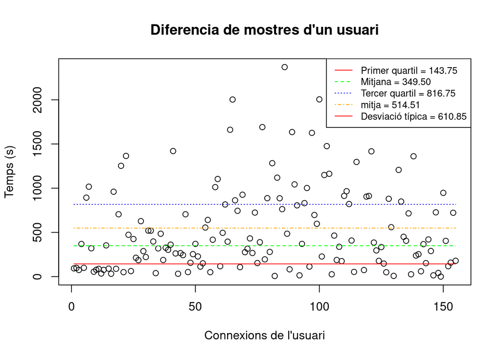

```r
usuari_gran = "00:15:6d:3c:fe:6c"
dades_usuari =  dades.train[usuari_gran == dades.train$clientmac, ]

dades_usuari = dades_usuari[order(dades_usuari$seentime),]
temps_diferencia = list()
for( i in 1:(length(dades_usuari$clientmac)-1)){
  diferencia = dades_usuari$seentime[i+1] -dades_usuari$seentime[i]
  temps_diferencia[i] = diferencia
}

vector = unlist(temps_diferencia)


primer_quartil = 143.75
primer_quartil = rep(primer_quartil, length(vector))

segon_quartil = 349.50
segon_quartil = rep(segon_quartil, length(vector))

tercer_quartil = 816.75
tercer_quartil = rep(tercer_quartil, length(vector))

deviacio_tipica = sd(vector)
#deviacio_tipica

mitja = sum(vector)/length(vector)
mitja = rep(mitja, length(vector))
#temps_diferencia
plot(vector, xlab = "Connexions de l'usuari", ylab ="Temps (s)", main = "Diferencia de mostres d'un usuari")
lines(primer_quartil, col = "red")
lines(segon_quartil, col = "green", lty = 2)
lines(tercer_quartil, col = "blue", lty = 3)
lines(mitja, col = "orange", lty = 4)
legend("topright", legend=c("Primer quartil = 143.75", "Mitjana = 349.50", "Tercer quartil = 816.75", "mitja = 514.51", "Desviació típica = 610.85"),
       col=c("red", "green", "blue", "orange"), lty=1:4, cex=0.8)
```

```r
min_contador = 3           # Mínim de vegades que ha d'estar conectat un dispositiu
habitual_usuari = list()   # Llistat de tots els usuaris
periode_eliminacio = 20000 # Ha d'estar en segons
ultima_entrada= NULL       # Última entrada per contar el temps



# Start the clock!
ptm <- proc.time()

for(i in 1:(length(dades.trainb$clientmac))){  #Se recorrerà tots els usuaris.
  usuari= dades.train[dades.trainb$clientmac[i] == dades.train$clientmac, ] #S'obtenen tots els registres d'un usuari

  for(j in 1:(length(usuari$clientmac))){ # Es recor tots els registres de l'usuari
   if(is.null(ultima_entrada)){
     ultima_entrada = usuari$seentime[j]

   }else if(periode_eliminacio > abs(ultima_entrada-usuari$seentime[j])){ # Si ni ho supera s'elimina
     usuari$seentime[j] = NA
   }else{
     ultima_entrada = usuari$seentime[j]
   }
  }
  usuari = usuari[!is.na(usuari$seentime),] # S'eliminen els NA, registres amb  poc temps
  ultima_entrada= NULL

  leng_usuari = length(usuari$clientmac)

  if(leng_usuari >= min_contador){ # Amb la longitud es decideix si es habitual o esporàdic
    habitual_usuari[i] = "habitual"
  } else {
    habitual_usuari[i] = "esporàdic"
  }
}

#Finish the clock
proc.time() -ptm
```

```
##    user  system elapsed
## 194.952   0.364 195.322
```

```r
dades.train_habituals = data.frame(unlist(habitual_usuari))

dades.train_habituals = data.frame(dades.trainb, "Classificació/E" = dades.train_habituals$unlist.habitual_usuari.)
```

```r
head(dades.train_habituals)
```

|  | idreg | clientmac | lat | lng | seendate | seentime | apmac | model | ssid | lloc | Assignment | Classificació.E |
| --- | --- | --- | --- | --- | --- | --- | --- | --- | --- | --- | --- | --- |
| 54950 | 3201376f-20b9-11ea-9849-080027f7d687 | 78:c3:e9:eb:62:4e | 39.57706 | 2.656507 | NA | 1563952642 | 00:18:0a:da:00:60 | NA | NA | NA | 78C3E9 | esporàdic |
| 1374722 | fd11e7b0-20ba-11ea-9849-080027f7d687 | d0:d2:b0:0d:e0:b1 | 39.57541 | 2.653006 | NA | 1563983657 | 88:15:44:59:61:e0 | NA | NA | NA | D0D2B0 | esporàdic |
| 3810489 | 0badf7c7-20be-11ea-9849-080027f7d687 | bc:54:51:6c:51:3a | 39.58093 | 2.655280 | NA | 1563954401 | 00:18:0a:5b:6b:70 | NA | NA | NA | BC5451 | esporàdic |
| 990317 | 7f3c425a-20ba-11ea-9849-080027f7d687 | 58:b1:0f:14:75:a4 | 39.56125 | 2.665809 | NA | 1563974826 | 00:18:0a:03:12:32 | NA | NA | NA | 58B10F | esporàdic |
| 3390841 | 7df493a9-20bd-11ea-9849-080027f7d687 | 80:58:f8:cd:13:fe | 39.56940 | 2.650101 | NA | 1563966259 | 00:18:0a:5b:36:20 | NA | NA | NA | 8058F8 | esporàdic |
| 3597353 | c3d00d2d-20bd-11ea-9849-080027f7d687 | b4:74:43:51:f8:1b | 39.55295 | 2.626896 | NA | 1563977668 | 00:18:0a:50:4d:da | NA | NA | NA | B47443 | esporàdic |

```r
str(dades.train_habituals)
```

```
## 'data.frame':    21374 obs. of  12 variables:
##  $ idreg          : Factor w/ 3833267 levels "000d4f7a-20bd-11ea-9849-080027f7d687",..: 732648 3787984 172041 1873852 1860237 2899557 2202554 1850091 1644039 471888 ...
##  $ clientmac      : Factor w/ 224375 levels "00:00:00:44:78:9c",..: 89608 184471 147926 63516 99770 141182 35700 10125 104692 1549 ...
##  $ lat            : num  39.6 39.6 39.6 39.6 39.6 ...
##  $ lng            : num  2.66 2.65 2.66 2.67 2.65 ...
##  $ seendate       : logi  NA NA NA NA NA NA ...
##  $ seentime       : int  1563952642 1563983657 1563954401 1563974826 1563966259 1563977668 1563977622 1563981272 1564002879 1563996266 ...
##  $ apmac          : Factor w/ 173 levels "00:18:0a:03:04:bc",..: 95 113 83 17 75 39 21 74 74 25 ...
##  $ model          : logi  NA NA NA NA NA NA ...
##  $ ssid           : logi  NA NA NA NA NA NA ...
##  $ lloc           : logi  NA NA NA NA NA NA ...
##  $ Assignment     : Factor w/ 2370 levels "0000AE","000272",..: 1184 1974 1782 922 1239 1696 563 248 1299 44 ...
##  $ Classificació.E: Factor w/ 2 levels "esporàdic","habitual": 1 1 1 1 1 1 1 1 1 2 ...
```

```r
summary(dades.train_habituals$ClassificacioH.E)
```

```
## Length  Class   Mode
##      0   NULL   NULL
```

```r
combinacio = data.frame("classificacioEH" = dades.train_habituals$Classificació.E, "macusuari" = dades.train_habituals$clientmac)
summary(combinacio)
```

```
##   classificacioEH              macusuari
##  esporàdic:20534   00:00:ae:a6:8b:3b:    1
##  habitual :  840   00:02:72:87:1d:83:    1
##                    00:03:7f:96:d7:f9:    1
##                    00:03:ac:19:18:0e:    1
##                    00:03:ac:1a:07:2f:    1
##                    00:03:ac:1b:9b:f2:    1
##                    (Other)          :21368
```

```r
dades.train_final = merge(dades.train, combinacio, by.x = "clientmac" , by.y = "macusuari")
summary(dades.train_final)
```

```
##              clientmac                                      idreg
##  00:15:6d:3c:fe:6c:  156   000d4fd3-20bd-11ea-9849-080027f7d687:    1
##  00:15:6d:53:91:1d:  144   000d4fef-20bd-11ea-9849-080027f7d687:    1
##  00:15:5d:1f:17:cf:  136   000d5013-20bd-11ea-9849-080027f7d687:    1
##  00:15:6d:fa:ee:7b:  119   000d50f3-20bd-11ea-9849-080027f7d687:    1
##  00:12:7b:46:80:e4:   93   000d5103-20bd-11ea-9849-080027f7d687:    1
##  e4:f8:9c:58:74:10:   85   000d513d-20bd-11ea-9849-080027f7d687:    1
##  (Other)          :37600   (Other)                             :38327
##       lat             lng        seendate          seentime
##  Min.   :39.51   Min.   :2.600   Mode:logical   Min.   :1.564e+09
##  1st Qu.:39.57   1st Qu.:2.644   NA's:38333     1st Qu.:1.564e+09
##  Median :39.57   Median :2.648                  Median :1.564e+09
##  Mean   :39.57   Mean   :2.648                  Mean   :1.564e+09
##  3rd Qu.:39.58   3rd Qu.:2.654                  3rd Qu.:1.564e+09
##  Max.   :39.63   Max.   :2.780                  Max.   :1.564e+09
##
##                apmac        model           ssid           lloc
##  88:15:44:59:61:e0: 1007   Mode:logical   Mode:logical   Mode:logical
##  00:18:0a:5b:31:90:  931   NA's:38333     NA's:38333     NA's:38333
##  88:15:44:2d:40:40:  927
##  e0:55:3d:10:07:9e:  898
##  00:18:0a:5b:48:d0:  874
##  00:18:0a:5b:33:00:  870
##  (Other)          :32826
##   classificacioEH
##  esporàdic:30382
##  habitual : 7951
##
##
##
##
##
```

## Estàtic o mòbil

Per poder identificar si els dispositius són estàtics o móbils. Per identificar si es estàtic o mòbil es pot mirar dues coses: - Nombre d’AP que es conecten - Distancia que recor

S’ha de tenir en compte que el dispositiu s’ha de veure més d’una vegada. El dispositiu ha de ser habitual per poder ser classificat.

```r
ap_estatic = 1
E_M_usuari = list()

# Start the clock!
ptm <- proc.time()
contador_estatic = 0
contador_mobil = 0




for(i in 1:(length(dades.trainb$clientmac))){  #Se recorrerà tots els usuaris.
  usuari = dades.train_final[dades.trainb$clientmac[i] == dades.train_final$clientmac, ] #S'obtenen tots els registres d'un usuari



usuari = usuari[!duplicated(usuari$apmac), ]
if(usuari$classificacioEH[1] == "esporàdic"){
  E_M_usuari[i] = "inclassificable"  #No se poden classificar per la falta de registres


}else if(length(usuari$apmac) == 1){
E_M_usuari[i] = "estàtic"  #Han de ser habituals
contador_estatic = contador_estatic + 1


} else{
E_M_usuari[i] = "mòbil"    # Pot ser esporàdic o habitual
contador_mobil = contador_mobil + 1

}


}
contador_estatic
```

```
## [1] 332
```

```r
contador_estatic/length(dades.trainb$clientmac)
```

```
## [1] 0.01553289
```

```r
contador_mobil
```

```
## [1] 508
```

```r
contador_mobil/length(dades.trainb$clientmac)
```

```
## [1] 0.02376719
```

Els resultats han donat que no s’han pogut classificar la majoria de dispositius. A causa de la petit percentatge recollit per realitzar-lo. On els dispositius mòbils són majors que els estàtics.